# Encuesta Nov-16 a la 2354 - Curso 2016-17

Lectura de los datos según la propuesta de Juanjo

```r
respuesta <- read.csv("Respuestas a TODOS los cuestionarios - Nov-16.csv", na = "NA")

names(respuesta) <- c("Marca.temporal","Numero.interno",
  "modelo","pregunta1","pregunta2","sexo","grupo",
  "primera.matricula","aprobado.esI","beca",
  "trabaja","estudios.madre","clasesnouniv",
  "copia","codificador","turno","aula")
respuesta <- respuesta[c(3:length(respuesta),1,2)]

respuesta$grupo <- as.factor(respuesta$grupo)
respuesta$Marca.temporal <- as.character(respuesta$Marca.temporal)
respuesta$Numero.interno <- as.character(respuesta$Numero.interno)
levels(respuesta$modelo)[1] <- "00"
levels(respuesta$estudios.madre)[2] <- "F.P."
```

# ¿Usan los alumnos servicios de academias o similares?

Indicar en un vector lógico qué individuos recibieron el tratamiento en esta pregunta (TRUE)

```r
tratam2 <- respuesta$modelo %in% c("01a","01b","1a1a","1b1b")
```

¿Cuántos individuos se sometieron al tratamiento y cuantos al control? ¿Cuántos fueron entrevistados en total? ¿Cuantos entregaron el cuestionario con todas las preguntas correctamente respondidas? ¿Y correctamente respondidas, al menos, las dos cuestiones relativas al tema de los inscritos en academias y similares?

```r
cbind(
  c("Control","Tratamiento","TOTAL","Cuestionarios correctos", "Correctas las cuestiones de academia"),
  c(sum(!tratam2), sum(tratam2), length(tratam2),sum(complete.cases(respuesta)),
    sum(complete.cases(respuesta[,c("pregunta2" ,"clasesnouniv" )]))
  )
)
```

```
##      [,1]                                   [,2]
## [1,] "Control"                              "220"
## [2,] "Tratamiento"                          "215"
## [3,] "TOTAL"                                "435"
## [4,] "Cuestionarios correctos"              "415"
## [5,] "Correctas las cuestiones de academia" "430"
```

Distribución de las respuestas a la lista según que el individuo recibiera (TRUE) o no (FALSE) el tratamiento. Debería observarse ausencia de fuertes efectos suelo o techo, y el valor modal debería ser el 2 si no se ha recibido tratamiento y debería ser 2 o 3 si se ha recibido (ver 4 pg. 518)

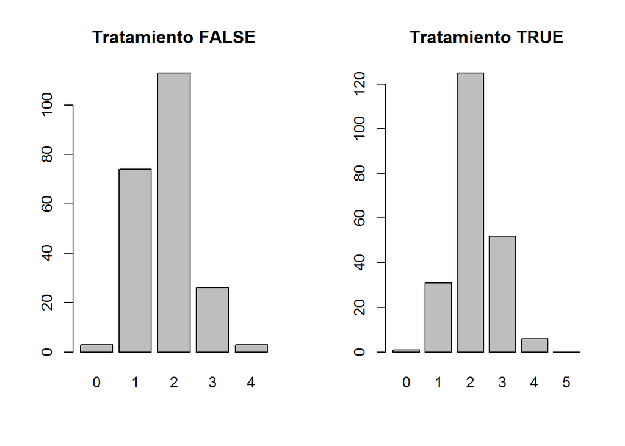

```r
par(mfrow=c(1,2))

plot(as.factor(respuesta$pregunta2[!tratam2]),main="Tratamiento FALSE")

muda <- as.factor(respuesta$pregunta2[tratam2])
if (!("5" %in% levels(muda))) {levels(muda)<-c(levels(muda),"5")}
plot(muda,main="Tratamiento TRUE");rm(muda)
```

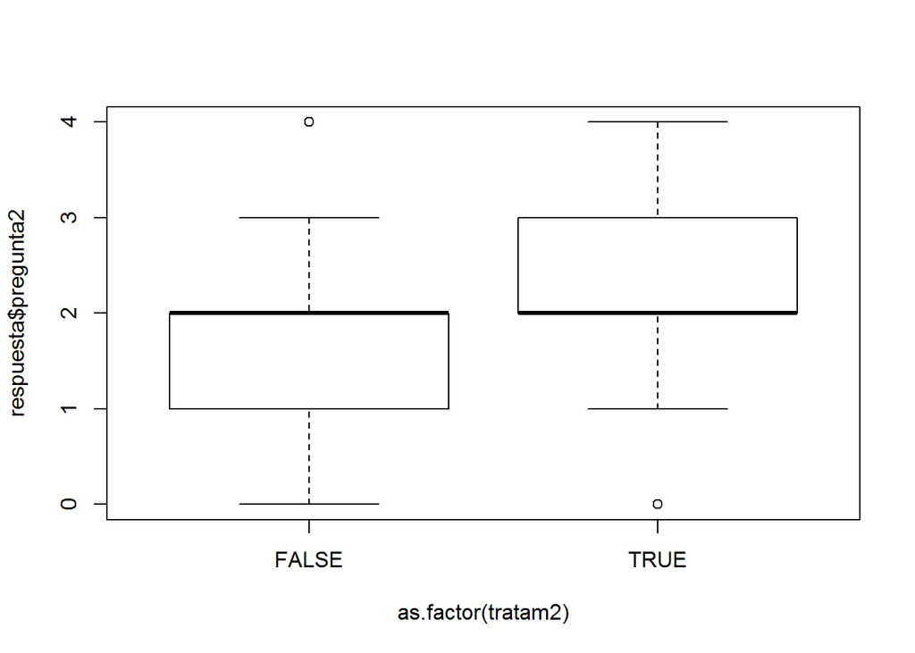

```r
par(mfrow=c(1,1))

plot(respuesta$pregunta2~as.factor(tratam2))
```

## Análisis descriptivo e inductivo de la PREGUNTA DIRECTA y del ESTIMADOR DIRECTO que se deriva de ella

Porcentaje muestral de encuestados que responden SI en la pregunta directa, calculado sobre cada una de las dos submuestras siguientes: la de los que reciben tratamiento y la de los que no. Contraste de la igualdad de los correspondientes porcentajes poblacionales (debería no rechazarse la nula si el hecho de ser sometido a tratamiento no influye en la respuesta a la pregunta directa cuando esta se hace al individuo con tratamiento, ver 4 pg. 518).

```r
attach(respuesta)
sum(clasesnouniv[tratam2]=="Si",na.rm=T)/sum(!is.na(clasesnouniv[tratam2]))
```

```
## [1] 0.3896714
```

```r
sum(clasesnouniv[!tratam2]=="Si",na.rm=T)/sum(!is.na(clasesnouniv[!tratam2]))
```

```
## [1] 0.3486239
```

```r
prop.test(
  x=c(sum(clasesnouniv[tratam2]=="Si",na.rm=T),sum(clasesnouniv[!tratam2]=="Si",na.rm=T)),
  n=c(sum(!is.na(clasesnouniv[tratam2])),sum(!is.na(clasesnouniv[!tratam2])))
)
```

```
##
##  2-sample test for equality of proportions with continuity
##  correction
##
## data:  c(sum(clasesnouniv[tratam2] == "Si", na.rm = T), sum(clasesnouniv[!tratam2] ==  out of c(sum(!is.na(clasesnouniv[tratam2])), sum(!is.na(clasesnouniv[!tratam2])))    "Si", na.rm = T)) out of c(sum(!is.na(clasesnouniv[tratam2])), sum(!is.na(clasesnouniv[!tratam2])))
## X-squared = 0.61335, df = 1, p-value = 0.4335
## alternative hypothesis: two.sided
## 95 percent confidence interval:
##  -0.0546472  0.1367422
## sample estimates:
##    prop 1    prop 2
## 0.3896714 0.3486239
```

### Estimador directo

Porcentaje de los que responden SI a la pregunta directa en toda la muestra. Esta última cantidad es el ESTIMADOR DIRECTO de la probabilidad de apuntarse a una academia habitualmente usado si no se aplica el tratamiento. Cálculo de la estimación de la desviación típica de ese estimador

```r
print( muda<-sum(clasesnouniv=="Si",na.rm=T)/sum(!is.na(clasesnouniv)) )    # ESTIMADOR DIRECTO
```

```
## [1] 0.3689095
```

```r
sqrt(muda*(1-muda)/sum(!is.na(clasesnouniv)))  # D.T. ESTIMADA DEL ESTIMADOR
```

```
## [1] 0.02324166
```

```r
rm(muda)
detach(respuesta)
```

## Análisis de los ESTIMADORES ESTÁNDAR (o CONVENCIONAL) y COMBINADO derivados de las LISTAS CON Y SIN TRATAMIENTO y de la PREGUNTA DIRECTA

### Estimador estándar o convencional

Cálculo de la respuesta media a la lista diferenciando entre individuos de tratamiento y de control. Cálculo de la diferencia entre ambas medias. Esta última cantidad es el ESTIMADOR ESTÁNDAR o CONVENCIONAL de la probabilidad de apuntarse a academias basado en el tratamiento (ver 1 pg.52). Cálculo de la estimación de la desviación típica de ese estimador (ver 2)

```r
print( mediasp2<-aggregate(respuesta$pregunta2,by=list(as.factor(tratam2)),FUN=mean,na.rm=T) )
```

```
##   Group.1        x
## 1   FALSE 1.780822
## 2    TRUE 2.144186
```

```r
mediasp2$x[2]-mediasp2$x[1]  ## ESTIMADOR ESTANDAR o CONVENCIONAL
```

```
## [1] 0.3633641
```

```r
attach(respuesta)
sqrt(var(pregunta2[tratam2],na.rm=T)/sum(!is.na(pregunta2[tratam2]))+
    var(pregunta2[!tratam2],na.rm=T)/sum(!is.na(pregunta2[!tratam2])))  # D.T. ESTIMADA DEL ESTIMADOR
```

```
## [1] 0.06850038
```

```r
detach(respuesta)
```

### Estimador combinado y aplicación de los Test placebo

Estimación de la probabilidad de que un alumno se apunte a una academia mediante el ESTIMADOR COMBINADO (ver 2 y 3 pg. 48) y estimación de la desviación típica del estimador. Se acompaña de otros estimadores ya calculados antes; las diferencias numéricas con los resultados previos deben estar originadas por el tratamiento que se da a las observaciones NA. Aplicación de los CONTRASTES PLACEBO I (H<sub>0</sub>: se cumplen todos los supuesos previos para la aplicación del estadístico combinado) y PLACEBO II (H<sub>0</sub>: se cumple el supuesto de independencia respecto del tratamiento, uno de los previos a la aplicación del estadístico combinado) (ver 3 pg. 50 a 51. Parece que lo que realmente contrasta PLACEBO II es la misma hipótesis que el test de igualdad de probabilidades realizado antes con prop.test. No se si son de hecho el mismo test o este de ahora es mas correcto y tiene en cuenta que los tamaños de cada muestra se han decidido aleatoriamente. Por otro lado, de las varias hipótesis que PLACEBO I contrasta simultáneamente, dos -ausencia de efecto debido al diseño y ausencia de mentirosos- son también previas a la aplicación del estadístico estándar o convencional (ver 1 pg. 52))

```r
library("list")
muda <- data.frame(Y=respuesta$pregunta2,Z=tratam2,D=(respuesta$clasesnouniv=="Si"))
muda <- combinedListDirect(formula = Y ~ Z, data = muda, treat = "Z", direct = "D")  # CALCULO CONJUNTO DE LOS DIFERENTES ESTIMADORES Y APLICACIÓN DE CONTRASTES PLACEBO
summary(muda)
```

```
##
##  Combined List Estimates
##
## Call: combinedListDirect(formula = Y ~ Z, data = muda, treat = "Z",
##     direct = "D")
##
##  Prevalence estimates
##                  Combined     Direct Conventional
## Estimate       0.40439069 0.36976744   0.35752147
## Standard Error 0.05875703 0.02330699   0.06894219
##
##  Placebo Test I
##        Beta is the conventional list experiment estimate among those who answer 'Yes' to the direct question.
##        Ho: beta = 1
##        Ha: beta != 1
##
##        Estimate       SE         p   n
## beta 0.8701649 0.101257 0.1997607 159
##
##  Placebo Test II
##        Delta is the average effect of the receiving the treatment list on the direct question response.
##        Ho: delta = 0
##        Ha: delta != 0
##
##          Estimate         SE         p   n
## delta 0.03944095 0.04664106 0.3977608 430
```

```r
rm(muda)
```

Dados los resultados de los contrastes realizados, parece que se dan las condiciones para que los estimadores estándar y combinado sean insesgados de la verdadera probabilidad de que un alumno se inscriba en una academia o similar, y también para que se pueda afirmar que el segundo estimador tendrá asintóticamente menor varianza que el primero (ver 3). Los resultados muestrales conseguidos apuntan también en la dirección de esa última afirmación. De manera MUY informal se puede observar que cada una de ambas estimaciones cae dentro del intervalo de confianza 95% que se genera con la otra.

### ¿Hay sesgo en el estimador directo?

¿Existe sesgo en la estimación que se obtiene del estimador directo clásico aplicado a la pregunta realizada directamente? Esta cuestión se puede plantear en otros términos: ¿existe tendencia a mentir sobre si se está apuntado a una academia, cuando esta pregunta se realiza de forma directa? Para responderla, se puede calcular el estimador estándar o convencional pero sobre dos submuestras: la de los que responden No a la pregunta directa y la de los que responden Si. Sobre la primera, el estimador debería ser insesgado de 0 si los que están apuntados no tienden a ocultarlo cuando se les pregunta directamente; y sobre la segunda debería ser insesgado de 1 si se cumple la hipótesis de monotonicidad (ver 3 pg.46), esto es, si nadie que no esté apuntado tiende a decir que lo está en una pregunta directa sobre ese aspecto (realmente esta hipótesis casi se puede dar por cierta por las propias características de la población y de la pregunta. Además estaría dentro del grupo de supuestos previos contrastados conjuntamente en el test Placebo I). Este tipo de cálculos ya se ha realizado previamente en la literatura pero no con este fin (ver 4 tabla 4 y pg. 522).

```r
attach(respuesta)
mediasp2porcnun<-aggregate(pregunta2,by=list(as.factor(tratam2),clasesnouniv),FUN=mean,na.rm=T)
mediasp2porcnun
```

```
##   Group.1 Group.2        x
## 1   FALSE      No 1.921986
## 2    TRUE      No 1.976923
## 3   FALSE      Si 1.539474
## 4    TRUE      Si 2.409639
```

```r
mediasp2porcnun$x[2]-mediasp2porcnun$x[1]  ## ESTIMADOR ESTANDAR ENTRE LOS QUE NO ACADEMIAS
```

```
## [1] 0.05493726
```

```r
sqrt(var(pregunta2[tratam2 & clasesnouniv=="No"],na.rm=T)/sum(!is.na(pregunta2[tratam2 & clasesnouniv=="No"]))+
    var(pregunta2[(!tratam2) & clasesnouniv=="No"],na.rm=T)/sum(!is.na(pregunta2[(!tratam2) & clasesnouniv=="No"])))  # D.T. ESTIMADA DEL ESTIMADOR
```

```
## [1] 0.08634042
```

```r
mediasp2porcnun$x[4]-mediasp2porcnun$x[3]  ## ESTIMADOR ESTANDAR ENTRE LOS QUE SI ACADEMIAS
```

```
## [1] 0.8701649
```

```r
sqrt(var(pregunta2[tratam2 & clasesnouniv=="Si"],na.rm=T)/sum(!is.na(pregunta2[tratam2 & clasesnouniv=="Si"]))+
    var(pregunta2[(!tratam2) & clasesnouniv=="Si"],na.rm=T)/sum(!is.na(pregunta2[(!tratam2) & clasesnouniv=="Si"])))  # D.T. ESTIMADA DEL ESTIMADOR
```

```
## [1] 0.101257
```

```r
detach(respuesta)
```

No parece que haya tendencia a mentir cuando un alumno se le pregunta directamente sobre esa misma cuestión. Por ello, parece que el estimador directo no tiene sesgo.

### Conclusiones sobre el empleo alternativo de los estimadores directo, estándar (o convencional) y combinado

De todo lo anterior parece deducirse que se cumplen las condiciones para que los estimadores estándar y combinado puedan usarse con el fin de estimar la probabilidad de que un alumno utilice lo servicios de una academia o similar y para que el segundo sea asintóticamente más eficiente que el primero. Pero igualmente se deduce que el estimador directo clásico también se puede emplear, lo cual, por otro lado, resulta recomendable por la rotunda ganancia en eficiencia que se produce. PIENSO QUE DEBIERON TENER UN ALTA RESPONSABILIDAD EN ELLO, tanto las condiciones de total anonimato en la encuesta realizada -condiciones sobre la que se hizo mucho hincapié al llevar a cabo la encuesta- como el hecho de que el encuestado respondiera directamente por si mismo al cuesionario sin la intervención de persona o sistema telefónico o informático interpuesto alguno.

Estimación en forma de intervalo que se obtendría con el estimador directo.

```r
prop.test(
  x=sum(respuesta$clasesnouniv=="Si",na.rm=T),n=sum(!is.na(respuesta$clasesnouniv))
)
```

```
##
##  1-sample proportions test with continuity correction
##
## data:  sum(respuesta$clasesnouniv == "Si", na.rm = T) out of sum(!is.na(respuesta$clasesnouniv)), null probability 0.5
## X-squared = 29.104, df = 1, p-value = 6.858e-08
## alternative hypothesis: true p is not equal to 0.5
## 95 percent confidence interval:
##  0.3235813 0.4166126
## sample estimates:
##         p
## 0.3689095
```

## MODELOS MULTIVARIANTES para explicar la probabilidad de apuntarse a una academia

### Estimación y análisis/crítica del modelo tal y como está propuesto en la literatura y empleando la librería `list` preparada al efecto

En (5) se proponen modelos multivariantes para explicar la probabilidad de apuntarse a una academia en función de las variables explicativas que se desee extraídas de entre las preguntas que se hicieron en la encuesta. Se proponen varias metodologías para estimar esos modelos. La sección 2.3 de esa referencia propone una metodología basada en la estimación de modelos no lineales por mínimos cuadrados, menos eficiente que las basadas en estimaciones máximo-verosímiles que propone en otras secciones, pero más sencilla de aplicar. Se basa en, POR UN LADO, modelizar con una binomial (cosa MUY DISCUTIBLE EN MI OPINION), la media de la respuesta a la lista sin la pregunta sensible, lo que conlleva que la probabilidad de éxito de esa binomial sea igual a un logit<sup>-1</sup> de una combinación lineal de las variables explicativas. Y, POR OTRO LADO, en modelizar la probabilidad de apuntarse a la academia según otro logit<sup>-1</sup> de otra combinación lineal de esas variables. La estimación de los coeficientes de ambas combinaciones lineales se realiza en dos etapas, comenzado por la estimación de los coeficentes de la respuesta media a la lista sin la pregunta sensible. La estimación de la primera etapa se puede hacer como un modelo lineal generalizado propiamente dicho o mediante un estimación mínimo cuadrática no lineal. ¿¿Sorprendentemente??, con ambas opciones coincide la estimación final del modelo en el que primera.matricula es la única variable explicativa:

```r
library("list")

casos <- complete.cases(respuesta[,c("pregunta2","primera.matricula")])
muda <- data.frame(respuesta[casos,],tratam2=as.integer(tratam2[casos]))
ictreg(pregunta2~primera.matricula,
  data=muda,treat="tratam2",J=4,method="nls",fit.nonsensitive="glm")
```

```
##
## Item Count Technique Regression
##
## Call: ictreg(formula = pregunta2 ~ primera.matricula, data = muda,
##     treat = "tratam2", J = 4, method = "nls", fit.nonsensitive = "glm")
##
## Coefficient estimates
##
##         sensitive.(Intercept) sensitive.primera.matriculaSi
##                    -0.4149439                    -0.3062739
##           control.(Intercept)   control.primera.matriculaSi
##                    -0.1251631                    -0.1689747
##
## Number of control items J set to 4. Treatment groups were indicated by '' and '' and the control group by ''.
```

```r
summary(
  modelonls <- ictreg(pregunta2~primera.matricula,
  data=muda,treat="tratam2",J=4,method="nls",fit.nonsensitive="nls")
)
```

```
##
## Item Count Technique Regression
##
## Call: ictreg(formula = pregunta2 ~ primera.matricula, data = muda,
##     treat = "tratam2", J = 4, method = "nls", fit.nonsensitive = "nls")
##
## Sensitive item
##                         Est.    S.E.
## (Intercept)         -0.41494 0.42809
## primera.matriculaSi -0.30627 0.59305
##
## Control items
##                         Est.    S.E.
## (Intercept)         -0.12516 0.07685
## primera.matriculaSi -0.16897 0.09888
##
## Residual standard error: 0.700359 with 211 degrees of freedom
##
## Number of control items J set to 4. Treatment groups were indicated by '' and '' and the control group by ''.
```

El coeficiente de primera.matricula explicando la probabilidad de estar matriculado en academias es claramente no significativo. A su vez, el coeficiente de esa variable explicando la respuesta media a la lista sin tratamiento tiene un nivel de significatividad entre 5% y 10%:

```r
paste0( 100*2*(1-pnorm(abs(modelonls$par.control[2]/modelonls$se.control[2]))), "%" )
```

```
## [1] "8.74840004670827%"
```

No tengo muy claro si se puede aplicar algún tipo de contraste de sinificatividad conjunta de ambos coeficientes. Que sean ambos nulos querría decir que el estar matriculado por primera vez no influye en la respuesta a la lista sin tratamiento ni en la probabilidad de estar matriculado en una academia. Si se eliminan ambos coeficientes, el modelo queda:

```r
summary(
  modelonls.sinpm <- ictreg(pregunta2~1,data=muda,treat="tratam2",
                            J=4,method="nls",fit.nonsensitive="nls")
  )
```

```
##
## Item Count Technique Regression
##
## Call: ictreg(formula = pregunta2 ~ 1, data = muda, treat = "tratam2",
##     J = 4, method = "nls", fit.nonsensitive = "nls")
##
## Sensitive item
##                 Est.    S.E.
## (Intercept) -0.58614 0.29944
##
## Control items
##                 Est.    S.E.
## (Intercept) -0.21278 0.04938
##
## Residual standard error: 0.708733 with 212 degrees of freedom
##
## Number of control items J set to 4. Treatment groups were indicated by '' and '' and the control group by ''.
```

Y el nivel de significatividad del termino constante en el logit<sup>-1</sup> de la probabilidad de apuntarse a una academia sería solo ligeramente superior al 5%:

```r
paste0( 100*2*(1-pnorm(abs(modelonls.sinpm$par.treat[1]/modelonls.sinpm$se.treat[1]))), "%" )
```

```
## [1] "5.02960733204167%"
```

Un valor de 0 en ese coeficiente equivale a un valor de 50% de probabilidad de apuntarse a academias pero debido a lo justo del nivel de significatividad anterior, yo no adoptaría esta hipótesis.

### Comprobación de la validez de los resultados que genera `list`

El funcionamiento del método de estimación descrito no resulta muy claro. Se procede a investigarlo. Por lo menos, parece que la primera etapa funciona como se describe en la referencia, lo cual se comprueba examinando la estimación con `glm` de una regresión logística para la respuesta a la lista sin la pregunta sensible entre los individuos de control. QUEDA PENDIENTE DE EXAMINAR LO QUE RESULTARIA ESA ESTIMACION PERO EMPLEANDO `nls`. REALMENTE, TRAS LEER LO QUE DICE LA REFERENCIA, ES ESTA ESTIMACION ALTERNATIVA LA QUE INTERESARÍA MAS EXAMINAR PARA VER COMO FUNCIONA LA QUE HACE `ictreg` DE `list`.

```r
glm( cbind(pregunta2,4-pregunta2)~primera.matricula, data=muda,subset=!tratam2,family=binomial )
```

```
##
## Call:  glm(formula = cbind(pregunta2, 4 - pregunta2) ~ primera.matricula,
##     family = binomial, data = muda, subset = !tratam2)
##
## Coefficients:
##         (Intercept)  primera.matriculaSi
##             -0.1252              -0.1690
##
## Degrees of Freedom: 216 Total (i.e. Null);  215 Residual
## Null Deviance:       126.1
## Residual Deviance: 124.5     AIC: 519.4
```

### Comparación con la estimaciones de planteamientos alternativos de los modelos

El disponer también de la contestación a la pregunta directa y el haber comprobado que posiblemente en ella no hay sesgo por ocultamento de la verdadera respuesta, permite que podamos estimar directamente una regresión logística con primera.matricula como variable explicativa de la probabilidad de apuntarse a una academia. El fin es comparar los resultados que se obtengan en esa estimación con las conclusiones de la estimación anterior relativos a ese mismo modelo. Existe una doble posibilidad: usar como muestra el conjunto de todos los alumnos entrevistados (los de control y con tratamiento juntos) ya que parece que no hay tendencia a mentir en esta pregunta, o solo los alumnos que han recibido el tratamiento (que en la estimación anterior eran los únicos que realmente aportaron datos a traves de sus respuestas a la lista, sobre si estaban o no matriculados en academia):

```r
summary(
  glm(cbind(as.integer(clasesnouniv=="Si"),1-as.integer(clasesnouniv=="Si"))~primera.matricula,
      data=muda,family=binomial)
)
```

```
##
## Call:
## glm(formula = cbind(as.integer(clasesnouniv == "Si"), 1 - as.integer(clasesnouniv ==
##     "Si")) ~ primera.matricula, family = binomial, data = muda)
##
## Deviance Residuals:
##    Min      1Q  Median      3Q     Max
## -1.181  -1.181  -0.708   1.174   1.736
##
## Coefficients:
##                     Estimate Std. Error z value Pr(>|z|)
## (Intercept)          -1.2559     0.1690  -7.433 1.06e-13 ***
## primera.matriculaSi   1.2647     0.2149   5.886 3.96e-09 ***
## ---
## Signif. codes:  0 '***' 0.001 '**' 0.01 '*' 0.05 '.' 0.1 ' ' 1
##
## (Dispersion parameter for binomial family taken to be 1)
##
##     Null deviance: 566.60  on 429  degrees of freedom
## Residual deviance: 529.47  on 428  degrees of freedom
## AIC: 533.47
##
## Number of Fisher Scoring iterations: 4
```

```r
summary(
  glm(cbind(as.integer(clasesnouniv=="Si"),1-as.integer(clasesnouniv=="Si"))~primera.matricula,
      data=muda[tratam2,],family=binomial)
)
```

```
##
## Call:
## glm(formula = cbind(as.integer(clasesnouniv == "Si"), 1 - as.integer(clasesnouniv ==
##     "Si")) ~ primera.matricula, family = binomial, data = muda[tratam2,
##     ])
##
## Deviance Residuals:
##     Min       1Q   Median       3Q      Max
## -1.0810  -1.0810  -0.7409   1.2770   1.6894
##
## Coefficients:
##                     Estimate Std. Error z value Pr(>|z|)
## (Intercept)          -1.1527     0.2341  -4.923 8.53e-07 ***
## primera.matriculaSi   0.9216     0.3012   3.060  0.00221 **
## ---
## Signif. codes:  0 '***' 0.001 '**' 0.01 '*' 0.05 '.' 0.1 ' ' 1
##
## (Dispersion parameter for binomial family taken to be 1)
##
##     Null deviance: 275.13  on 212  degrees of freedom
## Residual deviance: 265.37  on 211  degrees of freedom
##   (2 observations deleted due to missingness)
## AIC: 269.37
##
## Number of Fisher Scoring iterations: 4
```

Ciertamente, la semejanza entre los resultados es muy poca. Yo me atrevería a señalar, como causante de tal discrepancia, al modelo que se propone para explicar la respuesta a la lista sin tratamiento. Creo que dicho modelo es absurdo, máxime teniendo en cuenta cómo se diseñan las preguntas no sensibles de la lista para disminuir la varianza del estimador estándar o convencional de la probabilidad de apuntarse a una academia. Ese modelo equivocado provocaría una mala especificación de la media de dicha respuesta y esto, seguramente, genera que los estimadores que se emplean con la metodología propuesta en (5) no sean, ni siquiera, consistentes.

### Uso de una estimación del sesgo al contestar la pregunta directa, con el fin valorar la validez de los modelos multivariantes propuestos por la literatura

En la sección 2.2.1 de (1), empleando la contestación a la pregunta directa en experimentos en los que esta haya sido recogida (al menos en los individuos de control), se propone una estimación de la diferencia, en función de la variable explicativa que se desee, entre la probabilidad de que se conteste que se está apuntado a una academia cuando la pregunta se hace de forma directa y la probabilidad verdadera de ese hecho (en otras palabras, una estimación del sesgo en la contestación a la pregunta sensible cuando es hecha de forma directa). En esa estimación se usan los resultados derivados de la estimación, con primera.matrícula como variable explicativa, del modelo multivariante realizada con `ictreg` y los de la estimación de un modelo logit para esa probabilidad (usando datos de los individuos de control ya que a ellos se les ha hecho la pregunta sensible directamente). En este caso debería ser cero pues, como se ha comentado antes, no parece que en esta pregunta exista tendencia a mentir si se hace directamente (al menos así se ha detectado en la población completa en su conjunto):

```r
summary(
  modelodirecto <- glm(cbind(as.integer(clasesnouniv=="Si"),1-as.integer(clasesnouniv=="Si"))~primera.matricula,
                       data=muda[!tratam2,],family=binomial)
)
```

```
##
## Call:
## glm(formula = cbind(as.integer(clasesnouniv == "Si"), 1 - as.integer(clasesnouniv ==
##     "Si")) ~ primera.matricula, family = binomial, data = muda[!tratam2,
##     ])
##
## Deviance Residuals:
##     Min       1Q   Median       3Q      Max
## -1.2839  -0.6753  -0.6753   1.0745   1.7834
##
## Coefficients:
##                     Estimate Std. Error z value Pr(>|z|)
## (Intercept)          -1.3622     0.2446  -5.570 2.55e-08 ***
## primera.matriculaSi   1.6091     0.3089   5.208 1.90e-07 ***
## ---
## Signif. codes:  0 '***' 0.001 '**' 0.01 '*' 0.05 '.' 0.1 ' ' 1
##
## (Dispersion parameter for binomial family taken to be 1)
##
##     Null deviance: 290.57  on 216  degrees of freedom
## Residual deviance: 260.50  on 215  degrees of freedom
##   (3 observations deleted due to missingness)
## AIC: 264.5
##
## Number of Fisher Scoring iterations: 4
```

```r
predict(modelodirecto,newdata=data.frame(primera.matricula=c("No","Si")),type="response")
```

```
##         1         2
## 0.2038835 0.5614035
```

```r
predict(modelonls,newdata=data.frame(primera.matricula=c("No","Si")),type="response")
```

```
##
## List Experiment Prediction
##
## Proportion of affirmative responses to the sensitive item
##
## Prediction:
## Est. =  0.3977
##
## Prediction:
## Est. =  0.3271
```

Los resultados no son próximos a cero pero tampoco me extraña en este caso dada la poca credibilidad que he dado a los resultados derivados de `ictreg` a causa del modelo que se propone para explicar la respuesta a la lista sin tratamiento.

## Referencias

1. Blair, G, y Imai, K. (2012) Statistical Analysis of List Experiments. *Political Analysis* 20, 47-77.
2. Coppock, A. (2016) *Vignette del paquete list de R, en CRAN*. https://cran.r-project.org/web/packages/list/vignettes/combined-list.html
3. Aronow, P.; Coppock, A.; Crawford, F.W. y Green, D.P. (2015) Combining List Experiment and Direct Question Estimates of Sensitive Behavior Prevalence. *Journal of Survey Statistics and Methodology* 3, 43-66.
4. Lax, J.P.; Phillips, J.H. y Stollwerk, A.F. (2016) Are survey respondents lying about their support for same-sex marriage? Lessons from a list experiment. *Public Opinion Quarterly* 80 (2) 510-533.
5. Imai, K. (2011) Multivariate Regression Analysis for the Item Count Technique. *Journal of the American Statistical Association* 106 (494), 407-415.